# **Transferencia de Calor 1D**

## Juan David Argüello Plata

[figure not shown]

## Planteamiento del problema

Se busca analizar, mediante métodos analíticos y numéricos, la transferencia de calor en una barra cuadrangular bajo las siguientes suposiciones:

- Conductividad térmica constante.
- Conducción 1D (dirección x - línea verde en la Figura 1).
- Conducción estable (no transitoria).

[figure not shown]

*Figura 1.* Transferencia de calor por conducción.

## **1. Desarrollo teórico**

### 1.1. Sobre toda la barra

Del balance energético sobre toda la barra se obtiene lo siguiente: $$ \begin{equation} Q _g A \left(x - L \right) + K A \frac{dT}{dx} = 0 \tag{1} \label{Global} \end{equation} $$

```python
from sympy import init_session
init_session(use_latex=True)
```

```
IPython console for SymPy 1.4 (Python 3.7.4-32-bit) (ground types: python)

These commands were executed:
>>> from __future__ import division
>>> from sympy import *
>>> x, y, z, t = symbols('x y z t')
>>> k, m, n = symbols('k m n', integer=True)
>>> f, g, h = symbols('f g h', cls=Function)
>>> init_printing()

Documentation can be found at https://docs.sympy.org/1.4/
```

### Condiciones de frontera

Las condiciones de frontera sobre el dominio $\left(0 \leq x \leq L\right)$ son:

- $T (0) = T_0 \rightarrow$ Temperatura inicial.
- $q(L) = q_L = -K \frac{\partial T}{\partial x} \Big| _{x=L} = 0 \rightarrow$ Transferencia de calor por unidad de área en el extremo.

```python
"""
    Selecciona el valor de la temperatura inicial,
    la generación de calor, la conductividad térmica
    y la longitud.
"""
var = {
    'T_0':{
        'Valor':0,
        'Units': '°C'
    },
    'Q_g':{
        'Valor':100,
        'Units': 'W/m^3'
    },
    'K':{
        'Valor': 55,
        'Units': 'W/m \, °C'
    },
    'L':{
        'Valor':3,
        'Units':'m'
    }
}

from IPython.display import HTML, display
Prim = True
for const in var:
    if Prim:
        text = const[0] + '(0) = T_0 = '
        Prim = False
    else:
        text = const + '= '
    display(HTML('$' + text + str(var[const]['Valor']) + \
                 '\left[' + var[const]['Units'] + '\\right]$'))
```

$T(0) = T_0 = 0\left[°C\right]$

$Q_g= 100\left[W/m^3\right]$

$K= 55\left[W/m \, °C\right]$

$L= 3\left[m\right]$

Resolviendo la Ecuación 1 mediante *Sympy* (librería de Python), y empleando las condiciones de frontera respectivas, se obtiene la siguiente relación matemática para la temperatura en cualquier punto $x$.

```python
T = Function('T')
Q_g, A, K, L = symbols('Q_g A K L')
Ec = Eq(Q_g*A*(x-L) + K*A*T(x).diff(x),0)
sol = dsolve(Ec,ics={T(0):var['T_0']['Valor']})
sol
```

$\displaystyle T{\left(x \right)} = \frac{L Q_{g} x}{K} - \frac{Q_{g} x^{2}}{2 K}$

Sustituyendo los valores de generación de calor y conductividad térmica...

```python
constants = {Q_g:var['Q_g']['Valor'],
             K:var['K']['Valor'],
             L:var['L']['Valor']}
final = sol.subs(constants)
final
```

$\displaystyle T{\left(x \right)} = - \frac{10 x^{2}}{11} + \frac{60 x}{11}$

Que gráficamente representa lo siguiente:

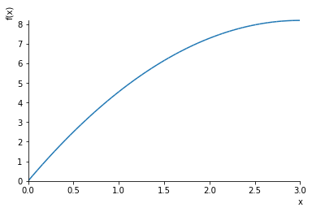

```
<sympy.plotting.plot.Plot at 0x5f48b10>
```

```python
%matplotlib inline
import matplotlib.pyplot as plt
sol = solve(final, T(x))
plot(sol[0], (x,0,var['L']['Valor']))
```

### 1.2. Sobre un Elemento Infinitesimal

[figure not shown]

*Figura 2.* Balance de energía sobre un elemento infinitesimal.

Desarrollando el balance de energía sobre el volumen de control inifinitesimal, se obtiene: $$ \begin{equation} 0 = \frac{d q_x}{d x} \Delta x - Q_g \Delta x \Delta y \Delta z \tag{2} \label{General} \end{equation} $$ Dónde: $\Delta x$, $\Delta y$ y $\Delta z$ son las longitudes inifinitesimales; y $Q_g$ es calor generado, por unidad de volumen, del elemento.

La Ecuación \ref{General} se puede relacionar con la Ley de Fourier (Ecuación \ref{fou}). $$ \begin{equation} q_x = -K \frac{d T}{d x} \Delta y \Delta z \tag{3} \label{fou} \end{equation} $$

Obteniéndose: $$ \begin{equation} \left[ -K \frac{d ^2 T}{d x ^2} - Q_g \right] \Delta x \Delta y \Delta z = 0 \rightarrow K \frac{d ^2 T}{d x ^2} + Q_g = 0 \tag{4} \label{DifGen} \end{equation} $$ La Ecuación \ref{DifGen} corresponde a la conservación de la energía dentro del volumen de control infinitesimal. Resolviendo mediante *Sympy*, se obtiene lo siguiente:

```python
Ec = Eq(K*T(x).diff(x,2) + Q_g,0)
sol = dsolve(Ec, ics={T(0):var['T_0']['Valor'], T(x).diff(x).subs(x,var['L']['Valor']):0})
sol
```

$\displaystyle T{\left(x \right)} = - \frac{Q_{g} x^{2}}{2 K} + \frac{3 Q_{g} x}{K}$

```python
constants = {Q_g:var['Q_g']['Valor'], K:var['K']['Valor']}
final = sol.subs(constants)
final
```

$\displaystyle T{\left(x \right)} = - \frac{10 x^{2}}{11} + \frac{60 x}{11}$

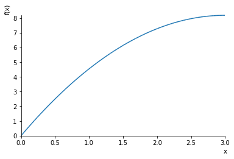

```
<sympy.plotting.plot.Plot at 0x5ec6630>
```

```python
%matplotlib inline
sol = solve(final, T(x))
plot(sol[0], (x,0,var['L']['Valor']))
```

La gráfica $\frac{dT}{dx}$ con respecto a $x$ (Ecuación 1) se puede apreciar a continuación.

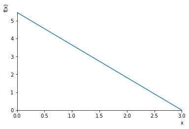

```
<sympy.plotting.plot.Plot at 0xda5b5f0>
```

```python
%matplotlib inline
Ec = Eq(K*T(x).diff(x) + Q_g,0)
sol = dsolve(Ec, ics={T(x).subs(x,var['L']['Valor']):0})
solution = solve(sol.subs(constants), T(x))
plot(solution[0], (x,0,var['L']['Valor']))
```

## **2. Solución Numérica**

El proceso de solución se basa en la *discretización*, que consiste en reducir el problema a la determinación de la temperatura en puntos específicos (**"nodos"**).

[figure not shown]

*Figura 3.* Discretización del problema.

De los nodos se puede definir la función de temperatura $T(x)$, donde los valores de temperatura entre nodos se obtienen mediante interpolación. Al final, se esperaría obtener una gráfica de temperatura como la mostrada en la Figura 4.

[figure not shown]

*Figura 4.* Gráfica de temperatura final esperada.

Este problema en particular tiene **4 nodos y 3 elementos**. Como se puede observar en la Figura 3, $T(x)$ es una función *a trozos*.

### 2.1. FDM

El desarrollo mediante el *Método de Diferencias Finitas* consiste en la conversión de la Ecuación 4 en un sistema matricial nodal, como se puede apreciar a continuación.

```python
#Número de nodos
n = 15
Ts = symbols('T_0:' + str(n))
l = Symbol('\Delta x')
#Condiciones internas
Ec = []
for i in range(1,n-1):
    Ec.append(Eq(K*(-2*Ts[i] + Ts[i-1] + Ts[i+1])/l**2 + Q_g,0))
#Condiciones de frontera
Ec.append(Eq(Ts[0], var['T_0']['Valor']))
Ec.append(Eq(-K*(Ts[-1] - Ts[-2])/l,0))
Ec
```

$\displaystyle \left[ \frac{K \left(T_{0} - 2 T_{1} + T_{2}\right)}{\Delta x^{2}} + Q_{g} = 0, \ \frac{K \left(T_{1} - 2 T_{2} + T_{3}\right)}{\Delta x^{2}} + Q_{g} = 0, \ \frac{K \left(T_{2} - 2 T_{3} + T_{4}\right)}{\Delta x^{2}} + Q_{g} = 0, \ \frac{K \left(T_{3} - 2 T_{4} + T_{5}\right)}{\Delta x^{2}} + Q_{g} = 0, \ \frac{K \left(T_{4} - 2 T_{5} + T_{6}\right)}{\Delta x^{2}} + Q_{g} = 0, \ \frac{K \left(T_{5} - 2 T_{6} + T_{7}\right)}{\Delta x^{2}} + Q_{g} = 0, \ \frac{K \left(T_{6} - 2 T_{7} + T_{8}\right)}{\Delta x^{2}} + Q_{g} = 0, \ \frac{K \left(T_{7} - 2 T_{8} + T_{9}\right)}{\Delta x^{2}} + Q_{g} = 0, \ \frac{K \left(T_{10} + T_{8} - 2 T_{9}\right)}{\Delta x^{2}} + Q_{g} = 0, \ \frac{K \left(- 2 T_{10} + T_{11} + T_{9}\right)}{\Delta x^{2}} + Q_{g} = 0, \ \frac{K \left(T_{10} - 2 T_{11} + T_{12}\right)}{\Delta x^{2}} + Q_{g} = 0, \ \frac{K \left(T_{11} - 2 T_{12} + T_{13}\right)}{\Delta x^{2}} + Q_{g} = 0, \ \frac{K \left(T_{12} - 2 T_{13} + T_{14}\right)}{\Delta x^{2}} + Q_{g} = 0, \ T_{0} = 0, \ - \frac{K \left(- T_{13} + T_{14}\right)}{\Delta x} = 0\right]$

La solución del sistema de ecuaciones mostrado es el siguiente:

```python
import numpy as np
difx = var['L']['Valor']/(n-1)
Ec = [Ts[0] - var['T_0']['Valor'], -var['K']['Valor']*(Ts[-1] - Ts[-2])/difx]
for i in range(1,n-1):
    Ec.append(var['K']['Valor']*(-2*Ts[i] + Ts[i-1] + Ts[i+1])/(difx)**2 +\
              var['Q_g']['Valor'])
sol, = linsolve(Ec, Ts)
Tss = np.zeros((2,n))
suma = 0
for i in range(len(sol)):
    suma += difx
    Tss[0][i] = sol[i]
    if i < len(sol)-1:
        Tss[1][i+1] += suma
    display(HTML('$T_{' + str(i) + '} = ' + str(round(sol[i],3)) + '$'))
```

$T_{0} = 0.0$

$T_{1} = 1.085$

$T_{2} = 2.087$

$T_{3} = 3.006$

$T_{4} = 3.84$

$T_{5} = 4.592$

$T_{6} = 5.26$

$T_{7} = 5.844$

$T_{8} = 6.345$

$T_{9} = 6.763$

$T_{10} = 7.096$

$T_{11} = 7.347$

$T_{12} = 7.514$

$T_{13} = 7.597$

$T_{14} = 7.597$

A continuación, se puede apreicar el comportamiento gráfico entre la *temperatura* y la *distancia*.

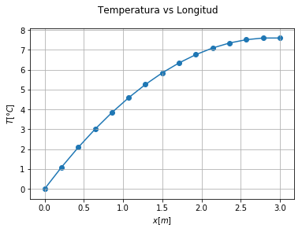

```python
%matplotlib inline
fig = plt.figure()
ax = fig.add_subplot(111)
ax.plot(
    Tss[1],
    Tss[0]
)
ax.scatter(
    Tss[1],
    Tss[0]
)
fig.suptitle('Temperatura vs Longitud')
ax.set_xlabel('$x [m]$')
ax.set_ylabel('$T \left[°C \\right]$')
ax.grid()
```

### 2.2. FEM

La lógica empleada en la solución numérica es la siguiente:

[figure not shown]

*Figura 5.* Lógica de solución.

En términos matemáticos, se resume en la solución de la ecuación matricial: $$ \begin{equation} \left[ K \right] \lbrace{ T \rbrace} = \lbrace{ Q \rbrace} \tag{5} \label{EcGeneral} \end{equation} $$ Dónde $K$ corresponde a la matriz de rigidez, $T$ al vector de temperatura y $Q$ al vector calor.

Durante el proceso de cálculo, las ecuaciones de los elementos del dominio discretizado (Figura 3) se *ensamblan* mediante la continuidad y/o balance de los principios físicos (conservación de la masa y la energía, por citar algunos ejemplos). En términos matemáticos: $$ \begin{equation} u \approx u_h = \sum _{j=1} ^n u_j \psi _j + \sum _{j=1} ^m c_j \phi _j \tag{6} \label{FEMprox} \end{equation} $$ De la Ecuación \ref{FEMprox}: $u_j$ son los valores de $u_h$ en los puntos nodales de cada elemento, $\psi _j$ son las funciones de interpolación, $c_j$ son los coeficientes *no* asociados con los nodos y $\phi _j$ son las funciones asociadas de aproximación.

### ¿Cómo derivar el sistema de ecuaciones algebraicas?

De la sección *Desarrollo teórico*, la Ecuación 4 muestra la forma diferencial del problema. La **forma integral ponderada** se puede apreciar en la Ecuación \ref{IntPond}. $$ \begin{equation} \int _0 ^L w \left(K \frac{\partial ^2 T}{\partial x ^2} + Q \right) \partial x = 0 \tag{7} \label{IntPond} \end{equation} $$ Dónde $w(x)$ es una función arbitraria. Cabe destacar que *la solución exacta se cumple para cualquier función arbitraria*.

Una forma "peculiar" de la Ecuación \ref{IntPond} es: $$ \begin{equation} \int _0 ^L w^e \left(K \frac{\partial ^2 T}{\partial x ^2} + Q \right) \partial x = 0 \tag{8} \label{IntPec} \end{equation} $$ Dónde $w^e (x)$ es una función polinómica a trozos.

Entre más nodos se usen, $w^e$ tenderá a ser $w$. La clave está en encontrar una función arbitraria que satisfaga la *función de forma*.

[figure not shown]

*Figura 6.* Función arbitraria.

### ¿Cómo encontrar las temperaturas nodales?

Cada ecuación relaciona la temperatura nodal con sus vecinos (ver Figura 4). Para solucionar la Ecuación \ref{IntPec}, se desarrolla [*integración por partes*](https://es.wikipedia.org/wiki/M%C3%A9todos_de_integraci%C3%B3n#M%C3%A9todo_de_integraci%C3%B3n_por_partes) $\left( \int u dv = uv - \int v du \right)$. $$ \begin{equation} w^e K \frac{\partial T}{\partial x} \Big| _0 ^L - K \int _0 ^L \frac{\partial w^e}{\partial x} \frac{\partial T}{\partial x} \partial x + \int _0 ^L w^e Q \partial x = 0 \tag{9} \label{EcNum} \end{equation} $$ La Ecuación \ref{EcNum} se conoce como la *forma débil* de la ecuación diferencial original.

A continuación, se desarrolla un análisis por términos de la Ecuación \ref{EcNum}.

1. El primer término, permite observar si se cumple la ley de la conservación de la energía. $$ w^e K \frac{\partial T}{\partial x} \Big| _0 ^L = K \left[ w_4 \left( \frac{\partial T}{\partial x} \right) _4 - w_1 \left( \frac{\partial T}{\partial x} \right) _1 \right] $$
2. El segundo término compete al desarrollo de la matriz de rigidez (Ecuación \ref{EcGeneral}).
3. El tercer término corresponde al *"término fuente"*. La integración se realiza elemento por elemento (ver Figuras 6 y 7). $$ \int _0 ^L w^e Q \partial x = Q \sum _{i=0} ^{n} \int _{i \Delta x} ^{\left(i+1 \right) \Delta x} w^e \partial x $$ Dónde $n=\# Elementos$. Por ejemplo: para el primer elemento... $$ Q \int _0 ^{\Delta x} w^e \partial x = Q \frac{\left(w_1 + w_2 \right) \Delta x}{2} $$

[figure not shown]

   *Figura 7.* Distribución de energía por elemento.